# Investigate a "No-show appointments" Dataset

## Introduction

- ‘ScheduledDay’ tells us on what day the patient set up their appointment.
- ‘Neighborhood’ indicates the location of the hospital.
- ‘Scholarship’ indicates whether or not the patient is enrolled in Brasilian welfare program Bolsa Família(opens in a new tab).

##### Be careful about the encoding of the last column: it says ‘No’ if the patient showed up to their appointment, and ‘Yes’ if they did not show up.

## This dataset was taken from [MedicalAppointmentNoShows](https://www.kaggle.com/datasets/joniarroba/noshowappointments).

#### Questions

- Q1: Does Gender Affect the Attendence?
- Q2: Does Age Affect the Attendance?
- Q3: Does Neighbourhood Affect the Attendance?
- Q4: Does Scholarship Affect the Attendance?
- Q5: Does SMS Affect the Attendance?
- Q6: Does Handicap Affect the Attendance?
- Q7: Does Age and Chronic Deseases (Diabetes, Hypertension) Affect the Attendence?
- Q8: Does Nighbourhood and Age Affect the Attendance?
- Q9: Does Neighbourhood and SMS Affect the Attendance?

## Importing the important librares

```python
#for data miniplation
import pandas as pd
#for claculation and arthmatic opration
import numpy as np
#for visulization
import matplotlib.pyplot as plt
#for visulization
import seaborn as sns
#for ploting the scatter plotting for all features as a matrix
from pandas.plotting import scatter_matrix
```

## For ignoring the wornings

```python
#for ignoring the non useful wornings
import warnings
warnings.filterwarnings('ignore')
```

## Read the csv file using pandas lib

```python
#read the files and print the filest 3 rows
df = pd.read_csv('kaggleV2-May-2016.csv')
df.head(3)
```

|  | PatientId | AppointmentID | Gender | ScheduledDay | AppointmentDay | Age | Neighbourhood | Scholarship | Hipertension | Diabetes | Alcoholism | Handcap | SMS_received | No-show |
| --- | --- | --- | --- | --- | --- | --- | --- | --- | --- | --- | --- | --- | --- | --- |
| 0 | 2.987250e+13 | 5642903 | F | 2016-04-29T18:38:08Z | 2016-04-29T00:00:00Z | 62 | JARDIM DA PENHA | 0 | 1 | 0 | 0 | 0 | 0 | No |
| 1 | 5.589978e+14 | 5642503 | M | 2016-04-29T16:08:27Z | 2016-04-29T00:00:00Z | 56 | JARDIM DA PENHA | 0 | 0 | 0 | 0 | 0 | 0 | No |
| 2 | 4.262962e+12 | 5642549 | F | 2016-04-29T16:19:04Z | 2016-04-29T00:00:00Z | 62 | MATA DA PRAIA | 0 | 0 | 0 | 0 | 0 | 0 | No |

## Shown the shape of the data frame

```python
#take the shape is number of columns and rows
rows, columns = df.shape
print(f'rows numbers {rows}')
print(f'columns numbers {columns}')
```

```
rows numbers 110527
columns numbers 14
```

## Shown all the columns and the data type of each one

```python
#show the info about the data
df.info()
```

```
<class 'pandas.core.frame.DataFrame'>
RangeIndex: 110527 entries, 0 to 110526
Data columns (total 14 columns):
 #   Column          Non-Null Count   Dtype
---  ------          --------------   -----
 0   PatientId       110527 non-null  float64
 1   AppointmentID   110527 non-null  int64
 2   Gender          110527 non-null  object
 3   ScheduledDay    110527 non-null  object
 4   AppointmentDay  110527 non-null  object
 5   Age             110527 non-null  int64
 6   Neighbourhood   110527 non-null  object
 7   Scholarship     110527 non-null  int64
 8   Hipertension    110527 non-null  int64
 9   Diabetes        110527 non-null  int64
 10  Alcoholism      110527 non-null  int64
 11  Handcap         110527 non-null  int64
 12  SMS_received    110527 non-null  int64
 13  No-show         110527 non-null  object
dtypes: float64(1), int64(8), object(5)
memory usage: 11.8+ MB
```

## Check if there is dublicate of all data points

```python
# check if there is any dublicate in all the data points
sum(df.duplicated())
```

```
0
```

## Check if there is null values on each row

```python
#see the number of null of each column
df.isna().sum()
```

```
PatientId         0
AppointmentID     0
Gender            0
ScheduledDay      0
AppointmentDay    0
Age               0
Neighbourhood     0
Scholarship       0
Hipertension      0
Diabetes          0
Alcoholism        0
Handcap           0
SMS_received      0
No-show           0
dtype: int64
```

## Show number of unique values of column **(PatientId)** in the data frame

```python
#number of unique data oint in column PatientId
df['PatientId'].nunique()
```

```
62299
```

## Show the number of dublicated values in column **(PatientId)** in the data frame

```python
#number of dublicated data points in column PatientId
sum(df['PatientId'].duplicated())
```

```
48228
```

## Show decibtive statistics about the data

```python
#show discibtive statistics about the data
df.describe()
```

|  | PatientId | AppointmentID | Age | Scholarship | Hipertension | Diabetes | Alcoholism | Handcap | SMS_received |
| --- | --- | --- | --- | --- | --- | --- | --- | --- | --- |
| count | 1.105270e+05 | 1.105270e+05 | 110527.000000 | 110527.000000 | 110527.000000 | 110527.000000 | 110527.000000 | 110527.000000 | 110527.000000 |
| mean | 1.474963e+14 | 5.675305e+06 | 37.088874 | 0.098266 | 0.197246 | 0.071865 | 0.030400 | 0.022248 | 0.321026 |
| std | 2.560949e+14 | 7.129575e+04 | 23.110205 | 0.297675 | 0.397921 | 0.258265 | 0.171686 | 0.161543 | 0.466873 |
| min | 3.921784e+04 | 5.030230e+06 | -1.000000 | 0.000000 | 0.000000 | 0.000000 | 0.000000 | 0.000000 | 0.000000 |
| 25% | 4.172614e+12 | 5.640286e+06 | 18.000000 | 0.000000 | 0.000000 | 0.000000 | 0.000000 | 0.000000 | 0.000000 |
| 50% | 3.173184e+13 | 5.680573e+06 | 37.000000 | 0.000000 | 0.000000 | 0.000000 | 0.000000 | 0.000000 | 0.000000 |
| 75% | 9.439172e+13 | 5.725524e+06 | 55.000000 | 0.000000 | 0.000000 | 0.000000 | 0.000000 | 0.000000 | 1.000000 |
| max | 9.999816e+14 | 5.790484e+06 | 115.000000 | 1.000000 | 1.000000 | 1.000000 | 1.000000 | 4.000000 | 1.000000 |

# Data Cleaning

## Cast all of there columns how dont need int64 to int16

```python
# Convert the 'Scholarship' column to int16 type to save memory and ensure consistency in data type.
df['Scholarship'] = df['Scholarship'].astype('int16')
# Convert the 'Hipertension' column to int16 type to save memory and ensure consistency in data type.
df['Hipertension'] = df['Hipertension'].astype('int16')
# Convert the 'Diabetes' column to int16 type to save memory and ensure consistency in data type.
df['Diabetes'] = df['Diabetes'].astype('int16')
# Convert the 'Alcoholism' column to int16 type to save memory and ensure consistency in data type.
df['Alcoholism'] = df['Alcoholism'].astype('int16')
# Convert the 'Handcap' column to int16 type to save memory and ensure consistency in data type.
df['Handcap'] = df['Handcap'].astype('int16')
# Convert the 'SMS_received' column to int16 type to save memory and ensure consistency in data type.
df['SMS_received'] = df['SMS_received'].astype('int16')
# Convert the 'Age' column to int16 type to save memory and ensure consistency in data type.
df['Age'] = df['Age'].astype('int16')
# Convert the 'PatientId' column to int64 type to ensure it can handle large values if needed.
df['PatientId'] = df['PatientId'].astype('int64')
# Convert the 'ScheduledDay' column to datetime type for easier manipulation and analysis of date and time data.
df['ScheduledDay'] = pd.to_datetime(df['ScheduledDay'])
# Display the information about the DataFrame, including the number of non-null entries and data types of each column.
df.info()
```

```
<class 'pandas.core.frame.DataFrame'>
RangeIndex: 110527 entries, 0 to 110526
Data columns (total 14 columns):
 #   Column          Non-Null Count   Dtype
---  ------          --------------   -----
 0   PatientId       110527 non-null  int64
 1   AppointmentID   110527 non-null  int64
 2   Gender          110527 non-null  object
 3   ScheduledDay    110527 non-null  datetime64[ns, UTC]
 4   AppointmentDay  110527 non-null  object
 5   Age             110527 non-null  int16
 6   Neighbourhood   110527 non-null  object
 7   Scholarship     110527 non-null  int16
 8   Hipertension    110527 non-null  int16
 9   Diabetes        110527 non-null  int16
 10  Alcoholism      110527 non-null  int16
 11  Handcap         110527 non-null  int16
 12  SMS_received    110527 non-null  int16
 13  No-show         110527 non-null  object
dtypes: datetime64[ns, UTC](1), int16(7), int64(2), object(4)
memory usage: 7.4+ MB
```

## Check if there is age less than 0 so it will be inserted by mistake

```python
#print the rows whos the age less than 0
df[df['Age'] < 0]
```

|  | PatientId | AppointmentID | Gender | ScheduledDay | AppointmentDay | Age | Neighbourhood | Scholarship | Hipertension | Diabetes | Alcoholism | Handcap | SMS_received | No-show |
| --- | --- | --- | --- | --- | --- | --- | --- | --- | --- | --- | --- | --- | --- | --- |
| 99832 | 465943158731293 | 5775010 | F | 2016-06-06 08:58:13+00:00 | 2016-06-06T00:00:00Z | -1 | ROMÃO | 0 | 0 | 0 | 0 | 0 | 0 | No |

## Remove the that row **(who cointain the age less than zero)**

```python
## remove it
df = df[df.Age >= 0]
```

## Rename the columns name to be as the standerd to deal with it

```python
# Dictionary mapping old column names to new column names
shown = {'No-show': 'No_show', 'Hipertension': 'Hypertension'}

# Rename the columns using map and a lambda function
df.columns = df.columns.map(lambda x: shown[x] if x in shown else x)

# Display the updated column names
df.columns
```

```
Index(['PatientId', 'AppointmentID', 'Gender', 'ScheduledDay',
       'AppointmentDay', 'Age', 'Neighbourhood', 'Scholarship', 'Hypertension',
       'Diabetes', 'Alcoholism', 'Handcap', 'SMS_received', 'No_show'],
      dtype='object')
```

## Drop the column that we dont need it on our analsys

```python
##drop two columns we dont need
df = df.drop(['AppointmentID', 'AppointmentDay'], axis=1)
df.head(0)
```

|  | PatientId | Gender | ScheduledDay | Age | Neighbourhood | Scholarship | Hypertension | Diabetes | Alcoholism | Handcap | SMS_received | No_show |
| --- | --- | --- | --- | --- | --- | --- | --- | --- | --- | --- | --- | --- |

## Exploratory Data Analysis

## Drow a histogram for all features with it counts

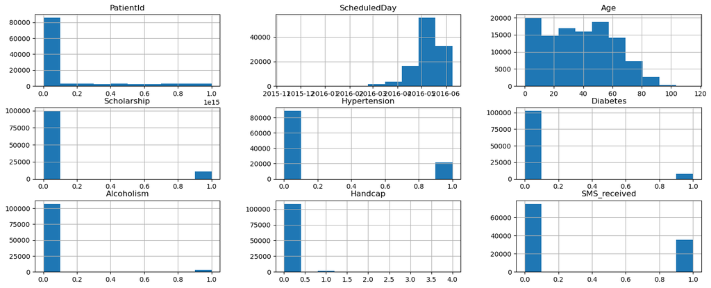

```python
#draw a histogram for all featurs spratly with it counts
df.hist(figsize=(18,7));
```

## Count plot for the Absent for the two gendars

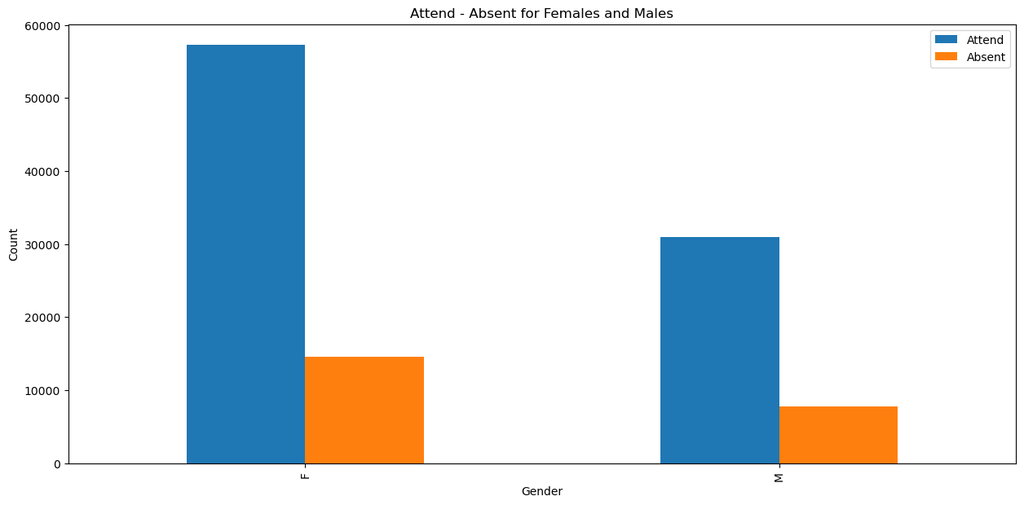

```python
# Create a figure and a set of subplots with the specified size
fig, axes = plt.subplots(figsize=(15, 7))
# Count the occurrences of each gender in the 'No_show' == 'No' (attended) group
attend_counts = df[df['No_show'] == 'No']['Gender'].value_counts()
# Count the occurrences of each gender in the 'No_show' == 'Yes' (absent) group
absent_counts = df[df['No_show'] == 'Yes']['Gender'].value_counts()
# Create a DataFrame with the counts of attend and absent grouped by gender
counts = pd.DataFrame({
    'Attend': attend_counts,
    'Absent': absent_counts
})
# Plot the counts as a bar plot on the specified axes
counts.plot(kind='bar', ax=axes)
# Set the title of the plot
axes.set_title('Attend - Absent for Females and Males')
# Set the label for the x-axis
axes.set_xlabel('Gender')
# Set the label for the y-axis
axes.set_ylabel('Count')
# Display the plot
plt.show()
```

## Tring to figuer out if there is a relation between all the features

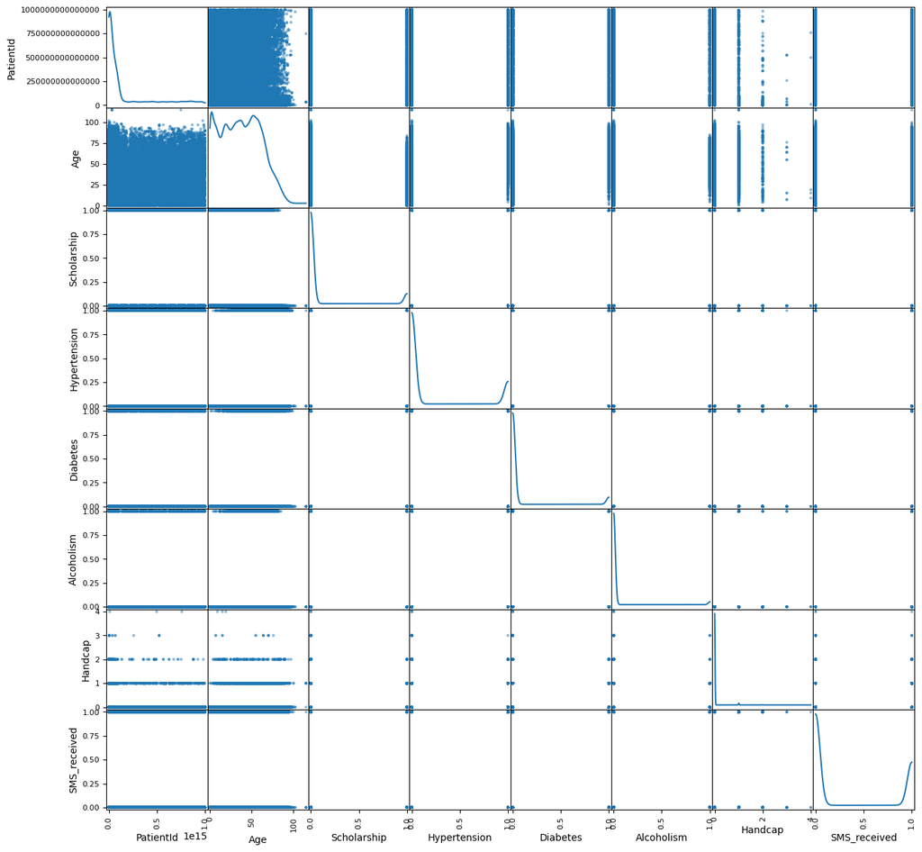

```python
#select the numaric types then built scatter blot on all the featues to show the corrolation
numeric_columns = df.select_dtypes(include=['int64', 'int16', 'float64'])
scatter_matrix(numeric_columns, figsize=(15, 15), diagonal='kde')
plt.show()
```